# 1_CiclosII

## SERIES DE TIEMPO PARA PRONÓSTICOS EN ECONOMÍA Y FINANZAS

### CLASE 5: Ciclos II - procesos ARMA

Elaborado por Jorge Guerra

@jguerrae18

ja.guerrae@uniandes.edu.co

```python
import warnings
warnings.filterwarnings("ignore") #código para ignorar los anuncios de alertas

from statsmodels.tools.sm_exceptions import ConvergenceWarning
warnings.simplefilter('ignore', ConvergenceWarning)
```

> **¿Qué haremos el día de hoy?**

El análisis se basará en una sola variable. La tasa de desempleo mensual en Colombia desde enero del año 2001 hasta el mes de noviembre del año 2019. La fuente de datos es el Departamento Administrativo Nacional de Estadística y la tasa de desempleo es la total Nacional. el código se dividirá en las siguientes secciones:

1. Exploración inicial
2. Modelos de brecha: AR(1).
3. Prónosticos fuera de muestra.
4. Criterios de selección.
5. Modelo estacionales y prónostico fuera de muestra.
6. Criterios de Selección de los modelos

```python
#IMPORTANDO LOS PAQUETES MÁS IMPORTANTES. RECORDANDO

import pandas as pd #Pandas para el procesamiento de los datos
import matplotlib.pyplot as plt #Matplotlib para gráficar
import seaborn as sns #Seaborn para gráficar
import numpy as np #Numpy para el procesamiento númerico
```

```python
df = pd.read_excel("desempleo.xlsx") #leer base de datos
```

```python
df["FECHA"] = pd.to_datetime(df["FECHA"]) #convertir en formato fecha
df = df.set_index("FECHA") #fijar la fecha como un índice ( ya no como columna)
df.index.freq = "MS" #Fijar frecuencia mensual
```

```python
df.describe() #descripción de la variable
```

|  | TD_SA |
| --- | --- |
| count | 227.000000 |
| mean | 11.369815 |
| std | 2.007538 |
| min | 8.542015 |
| 25% | 9.607702 |
| 50% | 11.028638 |
| 75% | 12.385207 |
| max | 16.552998 |

## 1. Exploración inicial

```python
from statsmodels.graphics.tsaplots import plot_acf,  plot_pacf #autocorrelación, autocorrelación parcial
```

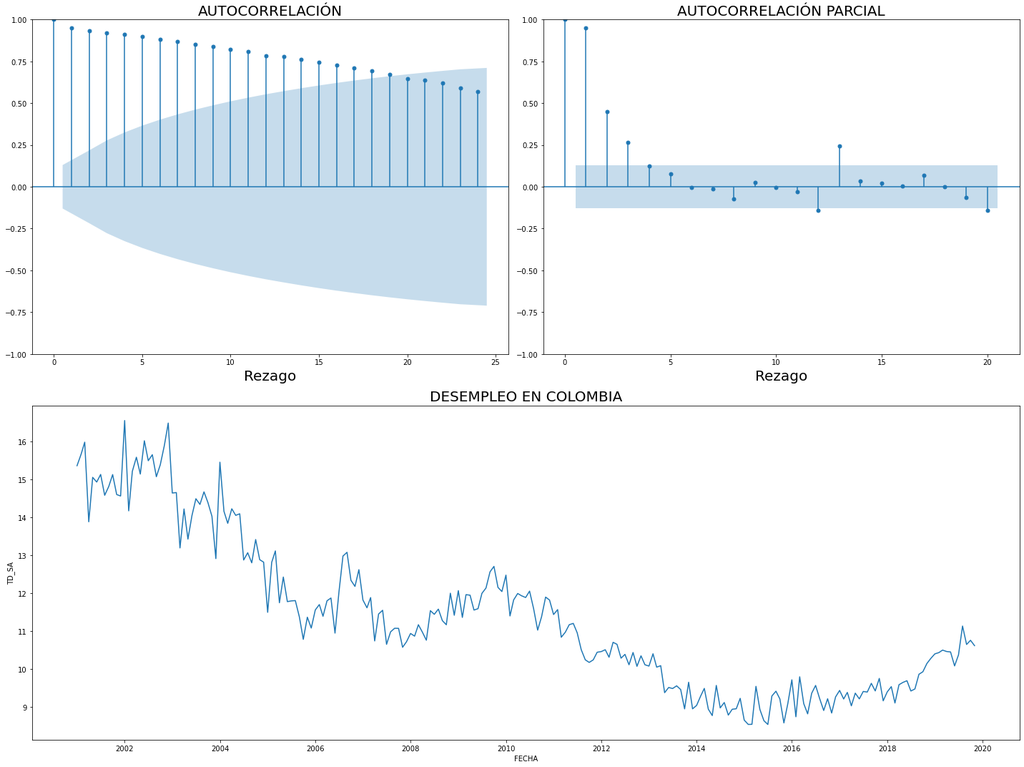

```python
fig = plt.figure(figsize=(20, 15))

ax1 = plt.subplot(221)
ax2 = plt.subplot(222)
ax3 = plt.subplot(212)


plot_acf(df.TD_SA, ax = ax1, alpha = 0.05)
ax1.set_xlabel('Rezago', fontsize=20)
ax1.set_title(r"AUTOCORRELACIÓN", fontsize=20)


plot_pacf(df.TD_SA, ax = ax2, lags  = 20, alpha = 0.05, method = "ols")
ax2.set_xlabel('Rezago', fontsize=20)
ax2.set_title(r"AUTOCORRELACIÓN PARCIAL", fontsize=20)

sns.lineplot(data = df, y = "TD_SA", x = "FECHA", dashes= True, err_style ="bars", ax = ax3)
ax3.set_title(r"DESEMPLEO EN COLOMBIA", fontsize=20)

plt.tight_layout()
plt.show()
```

## 2. Modelos ARIMA: estimando el mejor modelo.

### 2.1 Transformemos la serie con la primera diferencia para que sea estacionaria.

```python
df["DTD"] = df["TD_SA"].diff(1) #utilizamos .diff() para crear la primera diferencia
```

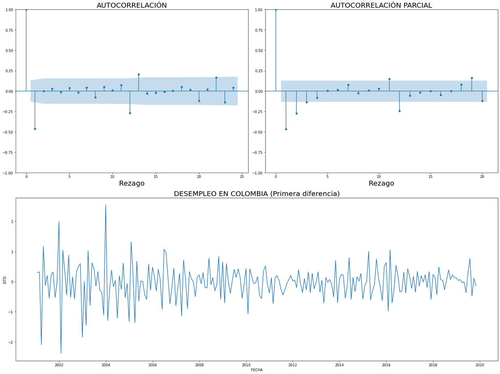

```python
#Exploración inicial

fig = plt.figure(figsize=(20, 15))

ax1 = plt.subplot(221)
ax2 = plt.subplot(222)
ax3 = plt.subplot(212)


plot_acf(df.DTD.dropna(), ax = ax1, alpha = 0.05) #agregamos el método .dropna() para eliminar los Nans
ax1.set_xlabel('Rezago', fontsize=20)
ax1.set_title(r"AUTOCORRELACIÓN", fontsize=20)


plot_pacf(df.DTD.dropna(), ax = ax2, lags  = 20, alpha = 0.05)
ax2.set_xlabel('Rezago', fontsize=20)
ax2.set_title(r"AUTOCORRELACIÓN PARCIAL", fontsize=20)

sns.lineplot(data = df, y = "DTD", x = "FECHA", dashes= True, err_style ="bars", ax = ax3)
ax3.set_title(r"DESEMPLEO EN COLOMBIA (Primera diferencia)", fontsize=20)

plt.tight_layout()
plt.show()
```

### 2.2 Estimemos diferentes modelos, variando el orden (p,q), para ver cuál es el mejor a través del BIC y el AIC.

#### Forma 1: Manualmente

```python
from statsmodels.tsa.arima.model import ARIMA
```

```python
#1 creamos los Dataframes vacíos
BM = pd.DataFrame(index = range(0,13), columns = range(0,13) )
AM = pd.DataFrame(index = range(0,13), columns = range(0,13) )

BM #¿Cómo se ve?
```

|  | 0 | 1 | 2 | 3 | 4 | 5 | 6 | 7 | 8 | 9 | 10 | 11 | 12 |
| --- | --- | --- | --- | --- | --- | --- | --- | --- | --- | --- | --- | --- | --- |
| 0 | NaN | NaN | NaN | NaN | NaN | NaN | NaN | NaN | NaN | NaN | NaN | NaN | NaN |
| 1 | NaN | NaN | NaN | NaN | NaN | NaN | NaN | NaN | NaN | NaN | NaN | NaN | NaN |
| 2 | NaN | NaN | NaN | NaN | NaN | NaN | NaN | NaN | NaN | NaN | NaN | NaN | NaN |
| 3 | NaN | NaN | NaN | NaN | NaN | NaN | NaN | NaN | NaN | NaN | NaN | NaN | NaN |
| 4 | NaN | NaN | NaN | NaN | NaN | NaN | NaN | NaN | NaN | NaN | NaN | NaN | NaN |
| 5 | NaN | NaN | NaN | NaN | NaN | NaN | NaN | NaN | NaN | NaN | NaN | NaN | NaN |
| 6 | NaN | NaN | NaN | NaN | NaN | NaN | NaN | NaN | NaN | NaN | NaN | NaN | NaN |
| 7 | NaN | NaN | NaN | NaN | NaN | NaN | NaN | NaN | NaN | NaN | NaN | NaN | NaN |
| 8 | NaN | NaN | NaN | NaN | NaN | NaN | NaN | NaN | NaN | NaN | NaN | NaN | NaN |
| 9 | NaN | NaN | NaN | NaN | NaN | NaN | NaN | NaN | NaN | NaN | NaN | NaN | NaN |
| 10 | NaN | NaN | NaN | NaN | NaN | NaN | NaN | NaN | NaN | NaN | NaN | NaN | NaN |
| 11 | NaN | NaN | NaN | NaN | NaN | NaN | NaN | NaN | NaN | NaN | NaN | NaN | NaN |
| 12 | NaN | NaN | NaN | NaN | NaN | NaN | NaN | NaN | NaN | NaN | NaN | NaN | NaN |

A través del método `.loc`, podemos acceder a cada [fila, columna] a través de su nombre.

```python
BM.loc[1,1]
```

```
nan
```

Con el fin de ver el grado y tiempo de avance utilizaremos el paquete `tqdm`.

```python
from tqdm import tqdm
```

Su sintaxis consiste en encerrar entre parentesis el objeto a iterar (rango, lista, diccionario) y la función irá mostrando el rango de avance.

```python
# LOOP PARA EL BIC

for p in range(0,13): #1 rango de orden p
    for q in tqdm(range(0,13)): # 2rango de orden q
        model = ARIMA(df["DTD"].dropna(), order=(p, 0, q)).fit() # 3 estimar el modelo arima de orden p,q
        BM.loc[p,q] = round(model.bic, 2) #4.1 redondeamos el valor del BIC a dos decimales
        AM.loc[p,q] = round(model.aic, 2) #4.2 redondeamos el valor del AIC a dos decimales

        # print(BM)
```

Tardó 3 minutos y 20 segundos en recorrer el loop, en Matlab tarda un tiempo similar (4 minutos y pico).

```python
#¿Cómo se ven?
AM
```

|  | 0 | 1 | 2 | 3 | 4 | 5 | 6 | 7 | 8 | 9 | 10 | 11 | 12 |
| --- | --- | --- | --- | --- | --- | --- | --- | --- | --- | --- | --- | --- | --- |
| 0 | 402.88 | 330.06 | 331.01 | 331.91 | 333.45 | 334.66 | 336.65 | 338.65 | 339.4 | 339.74 | 337.63 | 333.59 | 332.7 |
| 1 | 350.29 | 331.21 | 331.52 | 333.17 | 331.43 | 331.69 | 333.65 | 335.17 | 336.17 | 338.11 | 336.14 | 335.1 | 323.92 |
| 2 | 334.86 | 332.44 | 333.1 | 330.66 | 334.58 | 333.58 | 335.61 | 337.02 | 329.96 | 329.77 | 330.91 | 330.77 | 317.66 |
| 3 | 333.12 | 334.26 | 334.64 | 332.72 | 332.29 | 334.5 | 327.44 | 324.13 | 325.73 | 329.74 | 331.03 | 331.53 | 319.63 |
| 4 | 333.84 | 335.82 | 327.32 | 332.51 | 332.99 | 329.61 | 329.59 | 326.32 | 328.37 | 331.29 | 330.33 | 333.58 | 321.75 |
| 5 | 335.82 | 337.54 | 327.52 | 333.66 | 341.78 | 330.66 | 329.91 | 328.13 | 334.57 | 333.38 | 332.31 | 334.58 | 321.23 |
| 6 | 337.76 | 339.33 | 337.87 | 333.76 | 336.18 | 334.78 | 327.33 | 334.26 | 336.62 | 336.03 | 333.69 | 325.21 | 325.88 |
| 7 | 338.43 | 334.52 | 336.42 | 338.5 | 330.64 | 330.42 | 329.16 | 330.82 | 340.98 | 325.67 | 336.78 | 325.04 | 329.49 |
| 8 | 340.28 | 336.47 | 338.51 | 329.99 | 330.3 | 326.51 | 329.01 | 331.33 | 341.11 | 329.01 | 337.72 | 329.22 | 328.14 |
| 9 | 342.26 | 344.14 | 340.59 | 335.62 | 332.53 | 328.62 | 332.54 | 333.07 | 342.33 | 337.2 | 345.65 | 339.14 | 331.21 |
| 10 | 344.04 | 345.69 | 332.3 | 337.79 | 333.76 | 330.25 | 332.1 | 337.74 | 336.65 | 330.13 | 335.4 | 340.28 | 331.23 |
| 11 | 341.24 | 335.24 | 335.21 | 325.85 | 328.95 | 329.59 | 327.05 | 329.33 | 326.16 | 330.21 | 334.79 | 327.61 | 332.59 |
| 12 | 328.18 | 329.93 | 331.88 | 333.88 | 328.57 | 328.34 | 330.08 | 326.83 | 332.67 | 333.94 | 331.69 | 329.76 | 338.39 |

### Gráfica 3D

Miremos como se ven los anteriores datos en un plano 3D.

```python
from matplotlib import cm
```

```python
BMG = BM.iloc[1:, 1:].unstack().reset_index() #convertimos la base en un solo stack
BMG.columns = ["p", "q","BIC"] #cambiamos el nombre de las columnas
```

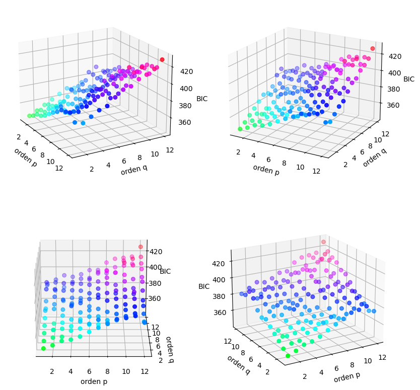

```python
# GRÁFICA BIC

fig = plt.figure(figsize=plt.figaspect(0.5))

#### ANGULO 20,330
ax = fig.add_subplot(2, 2, 1, projection='3d'); fig.set_size_inches(10, 10, forward=True); fig.set_dpi(100)
ax.scatter3D(BMG['p'], BMG['q'], BMG['BIC'], s=30,  cmap= cm.hsv, c = BMG["BIC"], vmin = 300)
ax.set_xlabel("orden p"); ax.set_ylabel("orden q"); ax.set_zlabel("BIC"); ax.view_init(20, 330)

#### ANGULO 20,300
ax = fig.add_subplot(2, 2, 2, projection='3d'); fig.set_size_inches(10, 10, forward=True); fig.set_dpi(100)
ax.scatter3D(BMG['p'], BMG['q'], BMG['BIC'], s=30,  cmap= cm.hsv, c = BMG["BIC"], vmin = 300)
ax.set_xlabel("orden p"); ax.set_ylabel("orden q"); ax.set_zlabel("BIC"); ax.view_init(20, 300)

##### ANGULO 20,270
ax = fig.add_subplot(2, 2, 3, projection='3d'); fig.set_size_inches(10, 10, forward=True); fig.set_dpi(100)
ax.scatter3D(BMG['p'], BMG['q'], BMG['BIC'], s=30,  cmap= cm.hsv, c = BMG["BIC"], vmin = 300)
ax.set_xlabel("orden p"); ax.set_ylabel("orden q"); ax.set_zlabel("BIC"); ax.view_init(20, 270)


##### ANGULO 20,240
ax = fig.add_subplot(2, 2, 4, projection='3d'); fig.set_size_inches(10, 10, forward=True); fig.set_dpi(100)
ax.scatter3D(BMG['p'], BMG['q'], BMG['BIC'], s=30,  cmap= cm.hsv, c = BMG["BIC"], vmin = 300)
ax.set_xlabel("orden p"); ax.set_ylabel("orden q"); ax.set_zlabel("BIC"); ax.view_init(20, 240)
```

El patrón del BIC parece ser muy estético pues parece un hiperplano en función de P y Q.

```python
AMG = AM.iloc[1:, 1:].unstack().reset_index()
AMG.columns = ["p", "q","AIC"]
```

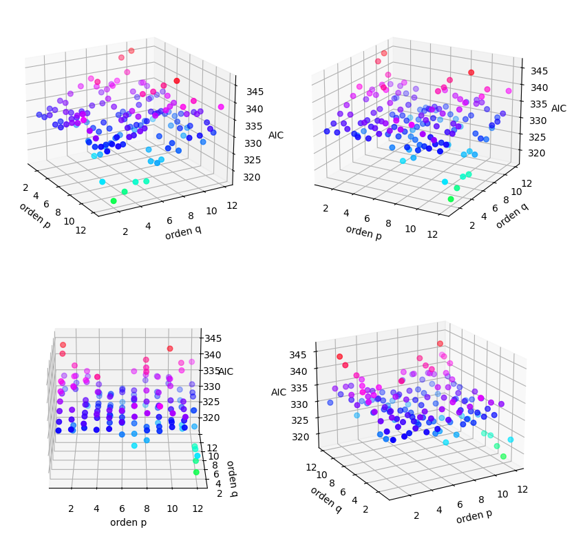

```python
# GRÁFICA AIC

fig = plt.figure(figsize=plt.figaspect(0.5))

ax = fig.add_subplot(2, 2, 1, projection='3d')
fig.set_size_inches(10, 10, forward=True)
fig.set_dpi(100)
ax.scatter3D(AMG['p'], AMG['q'], AMG['AIC'], s=30,  cmap=cm.hsv, c = AMG["AIC"], vmin = 300)
ax.set_xlabel("orden p")
ax.set_ylabel("orden q")
ax.set_zlabel("AIC")
# ax.set_xticks(AMG['p'])
ax.view_init(20, 330)

###
ax = fig.add_subplot(2, 2, 2, projection='3d')
fig.set_size_inches(10, 10, forward=True)
fig.set_dpi(100)
ax.scatter3D(AMG['p'], AMG['q'], AMG['AIC'], s=30,  cmap=cm.hsv, c = AMG["AIC"], vmin = 300)
ax.set_xlabel("orden p")
ax.set_ylabel("orden q")
ax.set_zlabel("AIC")
# ax.set_xticks(AMG['p'])
ax.view_init(20, 300)

#####
ax = fig.add_subplot(2, 2, 3, projection='3d')
fig.set_size_inches(10, 10, forward=True)
fig.set_dpi(100)
ax.scatter3D(AMG['p'], AMG['q'], AMG['AIC'], s=30,  cmap=cm.hsv, c = AMG["AIC"], vmin = 300)
ax.set_xlabel("orden p")
ax.set_ylabel("orden q")
ax.set_zlabel("AIC")
# ax.set_xticks(AMG['p'])
ax.view_init(20, 270)


ax = fig.add_subplot(2, 2, 4, projection='3d')
fig.set_size_inches(10, 10, forward=True)
fig.set_dpi(100)
ax.scatter3D(AMG['p'], AMG['q'], AMG['AIC'], s=30,  cmap=cm.hsv, c = AMG["AIC"], vmin = 300)
ax.set_xlabel("orden p")
ax.set_ylabel("orden q")
ax.set_zlabel("AIC")
# ax.set_xticks(AMG['p'])
ax.view_init(20, 240)
```

```python
##PARA EXTRAR EL MÍNIMO Y SUS INDICES, CONVERTIMOS EL DATAFRAME EN MATRIX

AMM = AM.to_numpy() #Ahora es un array de dos dimensiones
MinAIC = AMM.min() #Min AIC
MinAIC_pq = np.where(AMM == MinAIC) #Localizamos los indices
MinAIC_pq
```

```
(array([2], dtype=int64), array([12], dtype=int64))
```

El mejor modelo, según el AIC, es el de orden (p,q) = (2,12).

```python
##PARA EXTRAR EL MÍNIMO Y SUS INDICES, CONVERTIMOS EL DATAFRAME EN MATRIX

BMM = BM.to_numpy() #Ahora es un array de dos dimensiones
MinBIC = BMM.min() #Min AIC
MinBIC_pq = np.where(BMM == MinBIC) #Localizamos los indices
MinBIC_pq
```

```
(array([0], dtype=int64), array([1], dtype=int64))
```

El mejor modelo, según el BIC, es el de orden (p,q) = (0,1).

#### Forma 2: Autoarima

Esta forma es la misma anteriormente descrita solo que sin necesidad de hacer el loop. La idea es utilizar la función `auto_arima` del paquete `pmdarima` para que haga todo automaticamente. Pueden encontrar más información del paquete y la función [aquí](https://alkaline-ml.com/pmdarima/modules/generated/pmdarima.arima.auto_arima.html).

```python
#!pip install from pmdarima
# Instalamos el paquete en caso de no tenerlo
```

```python
from pmdarima.arima import auto_arima
```

```python
autoarima_TD = auto_arima(df["DTD"].dropna(), #Y
    start_p = 3, max_p = 12, #rango de p
    d = 0, max_d = 1, #rango de diferenciación
    start_q = 3,  max_q = 12, #rango de q
    information_criterion="bic", #criterio de selección
    with_intercept = True, #intercepto
    stepwise = False,
    method = "lbfgs",
    seasonal = False,
    trace = 1)

autoarima_TD
```

```
 ARIMA(0,0,0)(0,0,0)[0] intercept   : BIC=409.720, Time=0.10 sec
 ARIMA(0,0,1)(0,0,0)[0] intercept   : BIC=340.324, Time=0.17 sec
 ARIMA(0,0,2)(0,0,0)[0] intercept   : BIC=344.696, Time=0.21 sec
 ARIMA(0,0,3)(0,0,0)[0] intercept   : BIC=349.013, Time=0.29 sec
 ARIMA(0,0,4)(0,0,0)[0] intercept   : BIC=353.974, Time=0.42 sec
 ARIMA(0,0,5)(0,0,0)[0] intercept   : BIC=358.605, Time=0.87 sec
 ARIMA(1,0,0)(0,0,0)[0] intercept   : BIC=360.547, Time=0.08 sec
 ARIMA(1,0,1)(0,0,0)[0] intercept   : BIC=344.892, Time=0.28 sec
 ARIMA(1,0,2)(0,0,0)[0] intercept   : BIC=348.621, Time=0.53 sec
 ARIMA(1,0,3)(0,0,0)[0] intercept   : BIC=353.692, Time=0.84 sec
 ARIMA(1,0,4)(0,0,0)[0] intercept   : BIC=355.374, Time=0.57 sec
 ARIMA(2,0,0)(0,0,0)[0] intercept   : BIC=348.543, Time=0.07 sec
 ARIMA(2,0,1)(0,0,0)[0] intercept   : BIC=349.543, Time=0.24 sec
 ARIMA(2,0,2)(0,0,0)[0] intercept   : BIC=353.628, Time=0.55 sec
 ARIMA(2,0,3)(0,0,0)[0] intercept   : BIC=354.604, Time=1.10 sec
 ARIMA(3,0,0)(0,0,0)[0] intercept   : BIC=350.221, Time=0.16 sec
 ARIMA(3,0,1)(0,0,0)[0] intercept   : BIC=354.785, Time=0.49 sec
 ARIMA(3,0,2)(0,0,0)[0] intercept   : BIC=358.587, Time=0.91 sec
 ARIMA(4,0,0)(0,0,0)[0] intercept   : BIC=354.360, Time=0.18 sec
 ARIMA(4,0,1)(0,0,0)[0] intercept   : BIC=359.767, Time=0.51 sec
 ARIMA(5,0,0)(0,0,0)[0] intercept   : BIC=359.764, Time=0.23 sec

Best model:  ARIMA(0,0,1)(0,0,0)[0] intercept
Total fit time: 8.853 seconds
```

```
ARIMA(order=(0, 0, 1), scoring_args={}, suppress_warnings=True)
```

El igual que el método manual, la función `auto_arima` encontró que el mejor modelo era un ARMA de orden (p,q) = (0,1).

## 3. Mejor modelo

### AIC

```python
modelvf = ARIMA(df["TD_SA"].dropna(), order=(2, 1, 12)).fit()
print(modelvf.summary())
```

```
                               SARIMAX Results
==============================================================================
Dep. Variable:                  TD_SA   No. Observations:                  227
Model:                ARIMA(2, 1, 12)   Log Likelihood                -143.980
Date:                Sat, 05 Feb 2022   AIC                            317.960
Time:                        10:33:50   BIC                            369.268
Sample:                    01-01-2001   HQIC                           338.666
                         - 11-01-2019
Covariance Type:                  opg
==============================================================================
                 coef    std err          z      P>|z|      [0.025      0.975]
------------------------------------------------------------------------------
ar.L1         -0.7582      0.082     -9.256      0.000      -0.919      -0.598
ar.L2         -0.7076      0.086     -8.184      0.000      -0.877      -0.538
ma.L1          0.1860      0.111      1.675      0.094      -0.032       0.404
ma.L2          0.3333      0.115      2.897      0.004       0.108       0.559
ma.L3         -0.3538      0.100     -3.542      0.000      -0.550      -0.158
ma.L4          0.0185      0.072      0.256      0.798      -0.123       0.160
ma.L5          0.1617      0.074      2.177      0.029       0.016       0.307
ma.L6          0.0543      0.084      0.650      0.516      -0.109       0.218
ma.L7          0.1962      0.093      2.104      0.035       0.013       0.379
ma.L8         -0.1470      0.086     -1.702      0.089      -0.316       0.022
ma.L9          0.0811      0.074      1.095      0.273      -0.064       0.226
ma.L10         0.0381      0.073      0.519      0.604      -0.106       0.182
ma.L11         0.0421      0.070      0.605      0.545      -0.094       0.179
ma.L12        -0.3337      0.069     -4.840      0.000      -0.469      -0.199
sigma2         0.2037      0.022      9.291      0.000       0.161       0.247
===================================================================================
Ljung-Box (L1) (Q):                   0.07   Jarque-Bera (JB):                46.73
Prob(Q):                              0.80   Prob(JB):                         0.00
Heteroskedasticity (H):               0.25   Skew:                            -0.13
Prob(H) (two-sided):                  0.00   Kurtosis:                         5.21
===================================================================================

Warnings:
[1] Covariance matrix calculated using the outer product of gradients (complex-step).
```

```python
residuales = modelvf.resid[1:] #errores
```

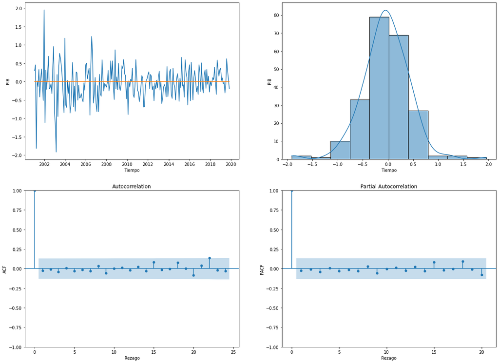

```python
#Inspección gráfica

fig, ax =plt.subplots(2,2, figsize=(20, 15), sharex = False)

#FIG 0,0
sns.lineplot(y = residuales, x = residuales.index, dashes= True, err_style ="bars", ax = ax[0, 0])
sns.lineplot(y = np.zeros(len(residuales)),  x = residuales.index, dashes= True, err_style ="bars", ax = ax[0, 0])
ax[0,0].set_xlabel('Tiempo', fontsize=10)
ax[0,0].set_ylabel('PIB', fontsize=10)


sns.histplot(x = residuales , ax=ax[0,1], bins = 10, kde = True)
ax[0,1].set_xlabel('Tiempo', fontsize=10)
ax[0,1].set_ylabel('PIB', fontsize=10)


#FIG 1
plot_acf(residuales, ax = ax[1,0], alpha = 0.05)
ax[1,0].set_xlabel('Rezago', fontsize=10)
ax[1,0].set_ylabel('ACF', fontsize=10)

#FIG 2
plot_pacf(residuales, ax = ax[1,1], lags  = 20, alpha = 0.05, method = "ols")
ax[1,1].set_xlabel('Rezago', fontsize=10)
ax[1,1].set_ylabel('PACF', fontsize=10)
```

### Q test

```python
from statsmodels.stats.diagnostic import acorr_ljungbox as QTest
```

```python
A = pd.DataFrame() #creamos un dataframe vacío

for i in range(5,16,5): #en un rango del 1 al 15 de 5 en 5 (...)
    B  = QTest(residuales, lags=[i], return_df=True) #Estimamos la prueba para cada uno de los rezagos y (...)
    A = pd.concat([A,B]) # la concatenamos verticalmente con las demás pruebas

A
```

|  | lb_stat | lb_pvalue |
| --- | --- | --- |
| 5 | 0.737674 | 0.980837 |
| 10 | 2.000572 | 0.996336 |
| 15 | 4.096345 | 0.997404 |

### Pronóstico

```python
UpCF1 = modelvf.get_forecast(steps = 13).conf_int(alpha = 0.025)["upper TD_SA"] #intervalo superior
LoCF1 = modelvf.get_forecast(steps = 13).conf_int(alpha = 0.025)["lower TD_SA"] #intervalo inferior
pred = modelvf.get_forecast(steps = 13).predicted_mean #media predicha
```

```python
sim = modelvf.simulate(13, anchor='end', repetitions=1000).T #simulación de 13 períodos con 1000 repeticiones cada una
simup = sim.quantile(0.975) #intervalo superior
simlo = sim.quantile(0.0275) #intervalo inferior
```

```python
ultimo_dato = df.TD_SA.iloc[::-1][0:1]
ultimo_dato #ultimo dato de la data de entrenamiento
```

```
FECHA
2019-11-01    10.619239
Freq: -1MS, Name: TD_SA, dtype: float64
```

```python
UpCF1 = pd.concat([ultimo_dato, UpCF1])
LoCF1 = pd.concat([ultimo_dato, LoCF1])
pred = pd.concat([ultimo_dato, pred])
simup = pd.concat([ultimo_dato, simup])
simlo = pd.concat([ultimo_dato, simlo])
```

```python
ultimo_dato
```

```
FECHA
2019-11-01    10.619239
Freq: -1MS, Name: TD_SA, dtype: float64
```

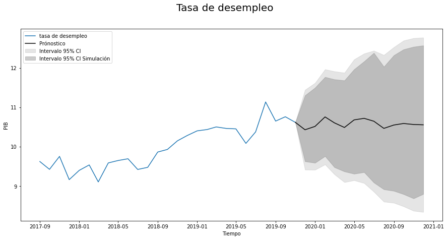

```python
fig = plt.figure( figsize=(15,7))

# (2) VARIABLES
sns.lineplot(x=df.index[200:], y=df.TD_SA[200:])

sns.lineplot(x=pred.index, y=pred, color = "black")

plt.fill_between(pred.index, LoCF1, UpCF1, color='gray', alpha=0.2)
# sns.lineplot(x=pred.index, y=UpCF1, color = "r", linestyle='--')
# sns.lineplot(pred.index, y=LoCF1, color='r', linestyle='--')

plt.fill_between(pred.index, simlo, simup, color='gray', alpha=0.4)
# sns.lineplot(x=pred.index, y=simup, color = "black", linestyle='--')
# sns.lineplot(pred.index, y=simlo, color='black', linestyle='--')

fig.suptitle('Tasa de desempleo', fontsize=20)
plt.xlabel('Tiempo', fontsize=10)
plt.ylabel('PIB', fontsize=10)
plt.ylabel('PIB', fontsize=10)
plt.legend(["tasa de desempleo", "Prónostico",
    "Intervalo 95% CI", "Intervalo 95% CI Simulación"],
    loc = "upper left" )



plt.show()
```

```python
simu_dic = sim.iloc[:, 0]
```

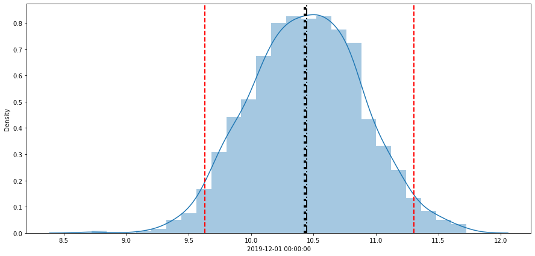

```python
fig = plt.figure( figsize=(15,7))

sns.distplot(simu_dic) #primer gráfico
plt.axvline(np.mean(simu_dic), color='black', linestyle='dashdot', lw=2)
plt.axvline(pred[1], color='black', linestyle='dotted', lw=4)

plt.axvline(simup[1], color='red', linestyle='--', lw=2)
plt.axvline(simlo[1], color='red', linestyle='--', lw=2)
```

### BIC

```python
modelvf = ARIMA(df["TD_SA"].dropna(), order=(0, 1, 1)).fit()
print(modelvf.summary())
```

```
                               SARIMAX Results
==============================================================================
Dep. Variable:                  TD_SA   No. Observations:                  227
Model:                 ARIMA(0, 1, 1)   Log Likelihood                -163.175
Date:                Sat, 05 Feb 2022   AIC                            330.351
Time:                        10:33:55   BIC                            337.192
Sample:                    01-01-2001   HQIC                           333.112
                         - 11-01-2019
Covariance Type:                  opg
==============================================================================
                 coef    std err          z      P>|z|      [0.025      0.975]
------------------------------------------------------------------------------
ma.L1         -0.5758      0.044    -13.110      0.000      -0.662      -0.490
sigma2         0.2477      0.015     16.240      0.000       0.218       0.278
===================================================================================
Ljung-Box (L1) (Q):                   0.67   Jarque-Bera (JB):                70.66
Prob(Q):                              0.41   Prob(JB):                         0.00
Heteroskedasticity (H):               0.23   Skew:                            -0.24
Prob(H) (two-sided):                  0.00   Kurtosis:                         5.70
===================================================================================

Warnings:
[1] Covariance matrix calculated using the outer product of gradients (complex-step).
```

```python
residuales = modelvf.resid[1:] #errores
```

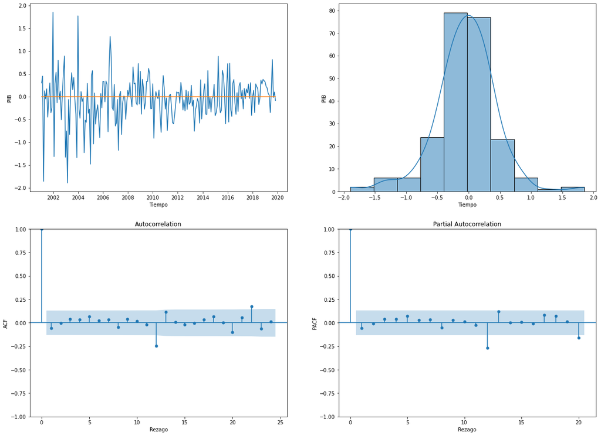

```python
#Inspección gráfica

fig, ax =plt.subplots(2,2, figsize=(20, 15), sharex = False)

#FIG 0,0
sns.lineplot(y = residuales, x = residuales.index, dashes= True, err_style ="bars", ax = ax[0, 0])
sns.lineplot(y = np.zeros(len(residuales)),  x = residuales.index, dashes= True, err_style ="bars", ax = ax[0, 0])
ax[0,0].set_xlabel('Tiempo', fontsize=10)
ax[0,0].set_ylabel('PIB', fontsize=10)


sns.histplot(x = residuales , ax=ax[0,1], bins = 10, kde = True)
ax[0,1].set_xlabel('Tiempo', fontsize=10)
ax[0,1].set_ylabel('PIB', fontsize=10)


#FIG 1
plot_acf(residuales, ax = ax[1,0], alpha = 0.05)
ax[1,0].set_xlabel('Rezago', fontsize=10)
ax[1,0].set_ylabel('ACF', fontsize=10)

#FIG 2
plot_pacf(residuales, ax = ax[1,1], lags  = 20, alpha = 0.05, method = "ols")
ax[1,1].set_xlabel('Rezago', fontsize=10)
ax[1,1].set_ylabel('PACF', fontsize=10)
```

### Q test

```python
from statsmodels.stats.diagnostic import acorr_ljungbox as QTest
```

```python
A = pd.DataFrame() #creamos un dataframe vacío

for i in range(5,16,5): #en un rango del 1 al 15 de 5 en 5 (...)
    B  = QTest(residuales, lags=[i], return_df=True) #Estimamos la prueba para cada uno de los rezagos y (...)
    A = pd.concat([A,B]) # la concatenamos verticalmente con las demás pruebas

A
```

|  | lb_stat | lb_pvalue |
| --- | --- | --- |
| 5 | 2.337811 | 0.800698 |
| 10 | 3.757085 | 0.957641 |
| 15 | 21.626107 | 0.117989 |

### Pronóstico

```python
UpCF1 = modelvf.get_forecast(steps = 13).conf_int(alpha = 0.025)["upper TD_SA"] #intervalo superior
LoCF1 = modelvf.get_forecast(steps = 13).conf_int(alpha = 0.025)["lower TD_SA"] #intervalo inferior
pred = modelvf.get_forecast(steps = 13).predicted_mean #media predicha
```

```python
sim = modelvf.simulate(13, anchor='end', repetitions=1000).T #simulación de 13 períodos con 1000 repeticiones cada una
simup = sim.quantile(0.975) #intervalo superior
simlo = sim.quantile(0.0275) #intervalo inferior
```

```python
ultimo_dato = df.TD_SA.iloc[::-1][0:1]
ultimo_dato #ultimo dato de la data de entrenamiento
```

```
FECHA
2019-11-01    10.619239
Freq: -1MS, Name: TD_SA, dtype: float64
```

```python
UpCF1 = pd.concat([ultimo_dato, UpCF1])
LoCF1 = pd.concat([ultimo_dato, LoCF1])
pred = pd.concat([ultimo_dato, pred])
simup = pd.concat([ultimo_dato, simup])
simlo = pd.concat([ultimo_dato, simlo])
```

```python
ultimo_dato
```

```
FECHA
2019-11-01    10.619239
Freq: -1MS, Name: TD_SA, dtype: float64
```

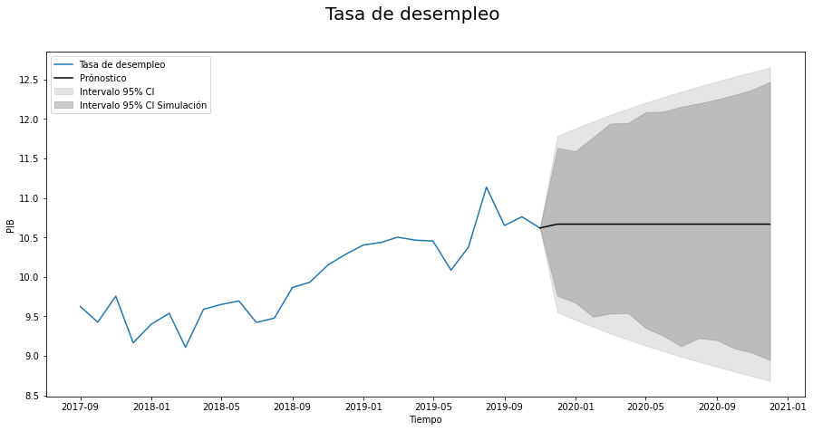

```python
fig = plt.figure( figsize=(15,7))

# (2) VARIABLES
sns.lineplot(x=df.index[200:], y=df.TD_SA[200:])

sns.lineplot(x=pred.index, y=pred, color = "black")

plt.fill_between(pred.index, LoCF1, UpCF1, color='gray', alpha=0.2)
# sns.lineplot(x=pred.index, y=UpCF1, color = "r", linestyle='--')
# sns.lineplot(pred.index, y=LoCF1, color='r', linestyle='--')

plt.fill_between(pred.index, simlo, simup, color='gray', alpha=0.4)
# sns.lineplot(x=pred.index, y=simup, color = "black", linestyle='--')
# sns.lineplot(pred.index, y=simlo, color='black', linestyle='--')

fig.suptitle('Tasa de desempleo', fontsize=20)
plt.xlabel('Tiempo', fontsize=10)
plt.ylabel('PIB', fontsize=10)
plt.legend(["Tasa de desempleo", "Prónostico",
    "Intervalo 95% CI", "Intervalo 95% CI Simulación"],
    loc = "upper left" )


plt.show()
```

```python
simu_dic = sim.iloc[:, 0]
```

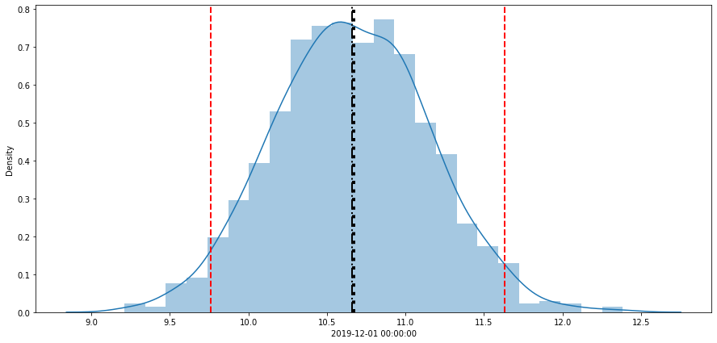

```python
fig = plt.figure( figsize=(15,7))

sns.distplot(simu_dic) #primer gráfico
plt.axvline(np.mean(simu_dic), color='black', linestyle='dashdot', lw=2)
plt.axvline(pred[1], color='black', linestyle='dotted', lw=4)

plt.axvline(simup[1], color='red', linestyle='--', lw=2)
plt.axvline(simlo[1], color='red', linestyle='--', lw=2)
```